# Executive summary

MEDV= 36.341 - 0.108×CRIM + 0.046×ZN + 2.719×CHAS - 17.376×NOX + 3.802×RM - 1.493×DIS + 0.300×RAD - 0.012×TAX – 0.947×PTRATIO + 0.009×B - 0.523×LSTAT

#Step 4 Check the linear regression assumptions

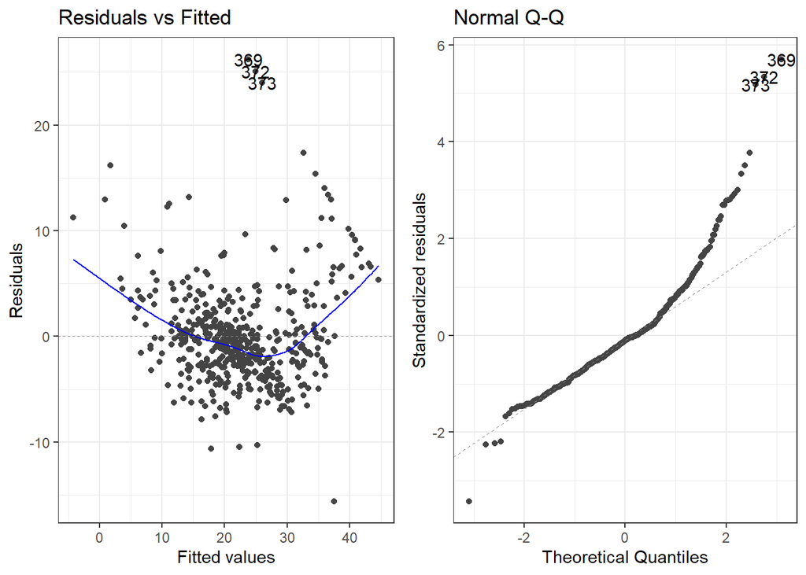

```r
library(ggfortify)
autoplot(boston_step, which = 1:2) + theme_bw()
```

#Step 5 What proportion of the variability of MEDV is explained by the explanatory variables in the step-wise selected model.

```r
summary(boston_step)
```

```
##
## Call:
## lm(formula = MEDV ~ CRIM + ZN + CHAS + NOX + RM + DIS + RAD +
##     TAX + PTRATIO + B + LSTAT, data = data)
##
## Residuals:
##      Min       1Q   Median       3Q      Max
## -15.5984  -2.7386  -0.5046   1.7273  26.2373
##
## Coefficients:
##               Estimate Std. Error t value Pr(>|t|)
## (Intercept)  36.341145   5.067492   7.171 2.73e-12 ***
## CRIM         -0.108413   0.032779  -3.307 0.001010 **
## ZN            0.045845   0.013523   3.390 0.000754 ***
## CHAS          2.718716   0.854240   3.183 0.001551 **
## NOX         -17.376023   3.535243  -4.915 1.21e-06 ***
## RM            3.801579   0.406316   9.356  < 2e-16 ***
## DIS          -1.492711   0.185731  -8.037 6.84e-15 ***
## RAD           0.299608   0.063402   4.726 3.00e-06 ***
## TAX          -0.011778   0.003372  -3.493 0.000521 ***
## PTRATIO      -0.946525   0.129066  -7.334 9.24e-13 ***
## B             0.009291   0.002674   3.475 0.000557 ***
## LSTAT        -0.522553   0.047424 -11.019  < 2e-16 ***
## ---
## Signif. codes:  0 '***' 0.001 '**' 0.01 '*' 0.05 '.' 0.1 ' ' 1
##
## Residual standard error: 4.736 on 494 degrees of freedom
## Multiple R-squared:  0.7406, Adjusted R-squared:  0.7348
## F-statistic: 128.2 on 11 and 494 DF,  p-value: < 2.2e-16
```

Relationship between Nitric Oxide Level and Housing Price

```r
library(ggfortify)
NO_HP = lm(MEDV ~ NOX , data)
summary(NO_HP)
```

```
##
## Call:
## lm(formula = MEDV ~ NOX, data = data)
##
## Residuals:
##     Min      1Q  Median      3Q     Max
## -13.691  -5.121  -2.161   2.959  31.310
##
## Coefficients:
##             Estimate Std. Error t value Pr(>|t|)
## (Intercept)   41.346      1.811   22.83   <2e-16 ***
## NOX          -33.916      3.196  -10.61   <2e-16 ***
## ---
## Signif. codes:  0 '***' 0.001 '**' 0.01 '*' 0.05 '.' 0.1 ' ' 1
##
## Residual standard error: 8.323 on 504 degrees of freedom
## Multiple R-squared:  0.1826, Adjusted R-squared:  0.181
## F-statistic: 112.6 on 1 and 504 DF,  p-value: < 2.2e-16
```

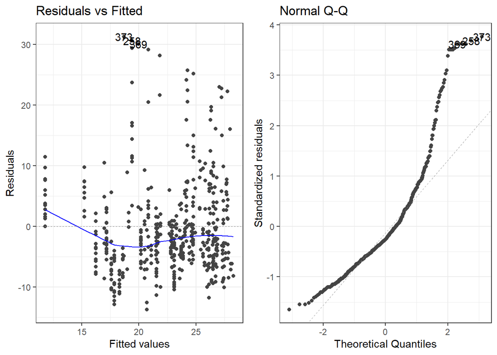

```r
autoplot(NO_HP, which = 1:2) + theme_bw()
```

Relationship between the per capita crime rate by town and Housing Price

```r
library(ggfortify)
CC_HP = lm(MEDV ~ CRIM , data)
summary(CC_HP)
```

```
##
## Call:
## lm(formula = MEDV ~ CRIM, data = data)
##
## Residuals:
##     Min      1Q  Median      3Q     Max
## -16.957  -5.449  -2.007   2.512  29.800
##
## Coefficients:
##             Estimate Std. Error t value Pr(>|t|)
## (Intercept) 24.03311    0.40914   58.74   <2e-16 ***
## CRIM        -0.41519    0.04389   -9.46   <2e-16 ***
## ---
## Signif. codes:  0 '***' 0.001 '**' 0.01 '*' 0.05 '.' 0.1 ' ' 1
##
## Residual standard error: 8.484 on 504 degrees of freedom
## Multiple R-squared:  0.1508, Adjusted R-squared:  0.1491
## F-statistic: 89.49 on 1 and 504 DF,  p-value: < 2.2e-16
```

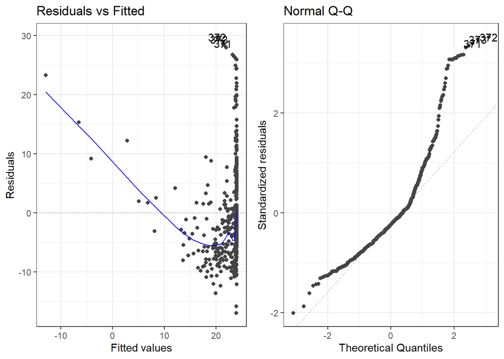

```r
autoplot(CC_HP, which = 1:2) + theme_bw()
```

#Relationship between the full-value property-tax rate by average number of rooms per dwelling#

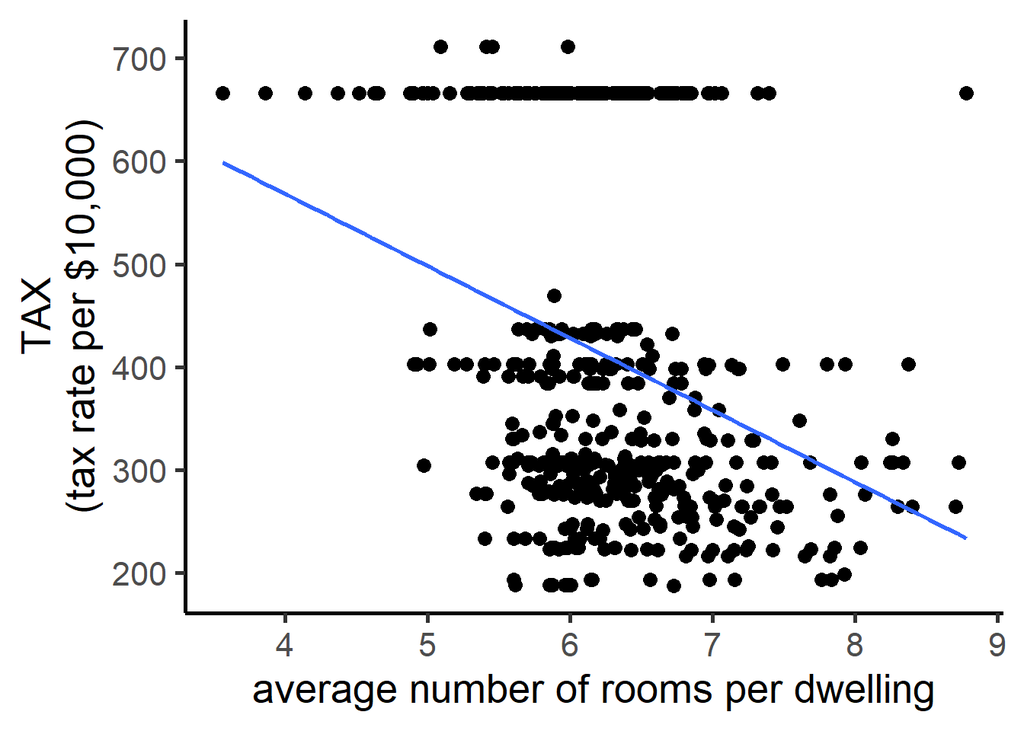

```r
p1 = ggplot(data, aes(x = RM,
                          y =TAX)) +
  geom_point(size = 3) +
  theme_classic(base_size = 20) +
  labs(x = "average number of rooms per dwelling",
       y = "TAX\n(tax rate per $10,000)") +
  geom_smooth(method = "lm", se = FALSE)
p1
```

```r
RM_TAX = lm(RM ~ TAX , data)
summary(RM_TAX)
```

```
##
## Call:
## lm(formula = RM ~ TAX, data = data)
##
## Residuals:
##      Min       1Q   Median       3Q      Max
## -2.40980 -0.43974 -0.05209  0.37595  2.80920
##
## Coefficients:
##               Estimate Std. Error t value Pr(>|t|)
## (Intercept)  6.7816725  0.0784284  86.470  < 2e-16 ***
## TAX         -0.0012175  0.0001776  -6.855 2.09e-11 ***
## ---
## Signif. codes:  0 '***' 0.001 '**' 0.01 '*' 0.05 '.' 0.1 ' ' 1
##
## Residual standard error: 0.6727 on 504 degrees of freedom
## Multiple R-squared:  0.08529,    Adjusted R-squared:  0.08348
## F-statistic:    47 on 1 and 504 DF,  p-value: 2.087e-11
```

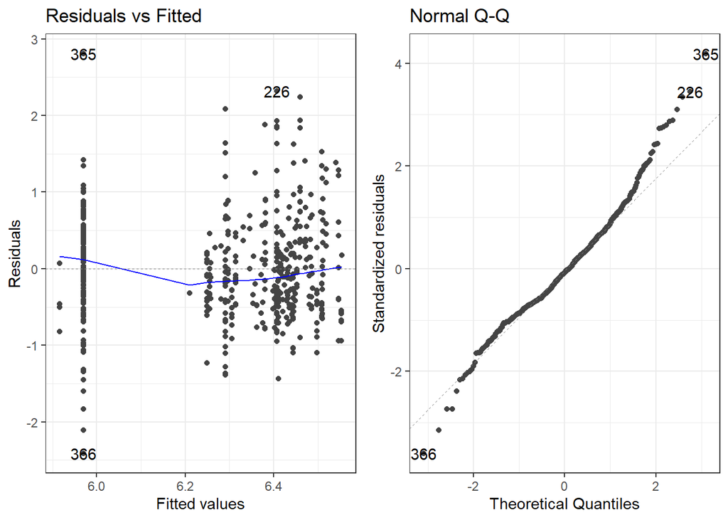

```r
autoplot(RM_TAX, which = 1:2) + theme_bw()
```

In the residual vs fitted values plot, there is no obvious pattern in the spread of the residuals across the range of fitted values. It looks like the homoskedasticity assumption is satisfied as the points are roughly equally spread over the range of fitted values.